# Netflix Title Data

Esther, Megan, Cynthia

11/5/2020

## Summary:

This is our report about Netflix Title Data. We are researching the overall topic of movies; what movies are popular, how many movies are released in a give year, how different movie streaming platforms differ, etc. This data set specifically covers movies that were added to Netflix from 2014 to 2019. The data set includes the following columns: Show ID, Type, Title, Director, Cast, County, Date Added, Release Year, Rating, Duration, Listed Genre, and a Description. We used a collection of these variables to perform our summary calculations.

# Summary information function

The most recent title added to Netflix is The Bling Ring. The average duration of movies on Netflix is 99.10082 minutes. The year with the most released titles was 2018. The most common T.V. show rating on Netflix is TV-MA. There are 2222 Netflix titles categorized under Dramas, and there are 668 titles listed under Documentaries.

# Aggregate Table

Netflix Data

| Release Year | Total Number of Netflix Entries In Year | Number of Movies | Number of TV Shows | Difference Between Number of Movies and TV Shows |
| --- | --- | --- | --- | --- |
| 1925 | 1 | 0 | 1 | -1 |
| 1942 | 2 | 2 | 0 | 2 |
| 1943 | 3 | 3 | 0 | 3 |
| 1944 | 3 | 3 | 0 | 3 |
| 1945 | 3 | 3 | 0 | 3 |
| 1946 | 3 | 2 | 1 | 1 |
| 1947 | 1 | 1 | 0 | 1 |
| 1954 | 1 | 1 | 0 | 1 |
| 1955 | 1 | 1 | 0 | 1 |
| 1956 | 1 | 1 | 0 | 1 |
| 1958 | 2 | 2 | 0 | 2 |
| 1959 | 1 | 1 | 0 | 1 |
| 1960 | 4 | 4 | 0 | 4 |
| 1962 | 3 | 3 | 0 | 3 |
| 1963 | 1 | 0 | 1 | -1 |
| 1964 | 1 | 1 | 0 | 1 |
| 1965 | 2 | 2 | 0 | 2 |
| 1966 | 1 | 1 | 0 | 1 |
| 1967 | 3 | 2 | 1 | 1 |
| 1968 | 4 | 3 | 1 | 2 |
| 1969 | 2 | 2 | 0 | 2 |
| 1970 | 1 | 1 | 0 | 1 |
| 1971 | 3 | 3 | 0 | 3 |
| 1972 | 4 | 3 | 1 | 2 |
| 1973 | 9 | 9 | 0 | 9 |
| 1974 | 8 | 7 | 1 | 6 |
| 1975 | 5 | 5 | 0 | 5 |
| 1976 | 7 | 7 | 0 | 7 |
| 1977 | 5 | 4 | 1 | 3 |
| 1978 | 7 | 7 | 0 | 7 |
| 1979 | 7 | 6 | 1 | 5 |
| 1980 | 7 | 7 | 0 | 7 |
| 1981 | 7 | 6 | 1 | 5 |
| 1982 | 11 | 11 | 0 | 11 |
| 1983 | 9 | 9 | 0 | 9 |
| 1984 | 8 | 8 | 0 | 8 |
| 1985 | 8 | 7 | 1 | 6 |
| 1986 | 10 | 8 | 2 | 6 |
| 1987 | 5 | 5 | 0 | 5 |
| 1988 | 13 | 11 | 2 | 9 |
| 1989 | 11 | 10 | 1 | 9 |
| 1990 | 15 | 12 | 3 | 9 |
| 1991 | 15 | 14 | 1 | 13 |
| 1992 | 16 | 14 | 2 | 12 |
| 1993 | 19 | 16 | 3 | 13 |
| 1994 | 14 | 13 | 1 | 12 |
| 1995 | 17 | 15 | 2 | 13 |
| 1996 | 17 | 14 | 3 | 11 |
| 1997 | 31 | 27 | 4 | 23 |
| 1998 | 26 | 23 | 3 | 20 |
| 1999 | 21 | 17 | 4 | 13 |
| 2000 | 31 | 28 | 3 | 25 |
| 2001 | 34 | 30 | 4 | 26 |
| 2002 | 38 | 35 | 3 | 32 |
| 2003 | 43 | 35 | 8 | 27 |
| 2004 | 49 | 40 | 9 | 31 |
| 2005 | 63 | 51 | 12 | 39 |
| 2006 | 68 | 59 | 9 | 50 |
| 2007 | 71 | 60 | 11 | 49 |
| 2008 | 107 | 87 | 20 | 67 |
| 2009 | 121 | 87 | 34 | 53 |
| 2010 | 149 | 111 | 38 | 73 |
| 2011 | 136 | 100 | 36 | 64 |
| 2012 | 183 | 125 | 58 | 67 |
| 2013 | 237 | 177 | 60 | 117 |
| 2014 | 288 | 213 | 75 | 138 |
| 2015 | 517 | 363 | 154 | 209 |
| 2016 | 830 | 593 | 237 | 356 |
| 2017 | 959 | 682 | 277 | 405 |
| 2018 | 1063 | 646 | 417 | 229 |
| 2019 | 843 | 400 | 443 | -43 |
| 2020 | 25 | 6 | 19 | -13 |

The most pertinent observations from the aggregate table is that the number of TV shows and movies clearly increase in the early 2000’s, and the number of movies increases at a higher rate than TV shows other than 1925, 1963, 2019, and 2020.

# Purposes of each chart

Chart 1

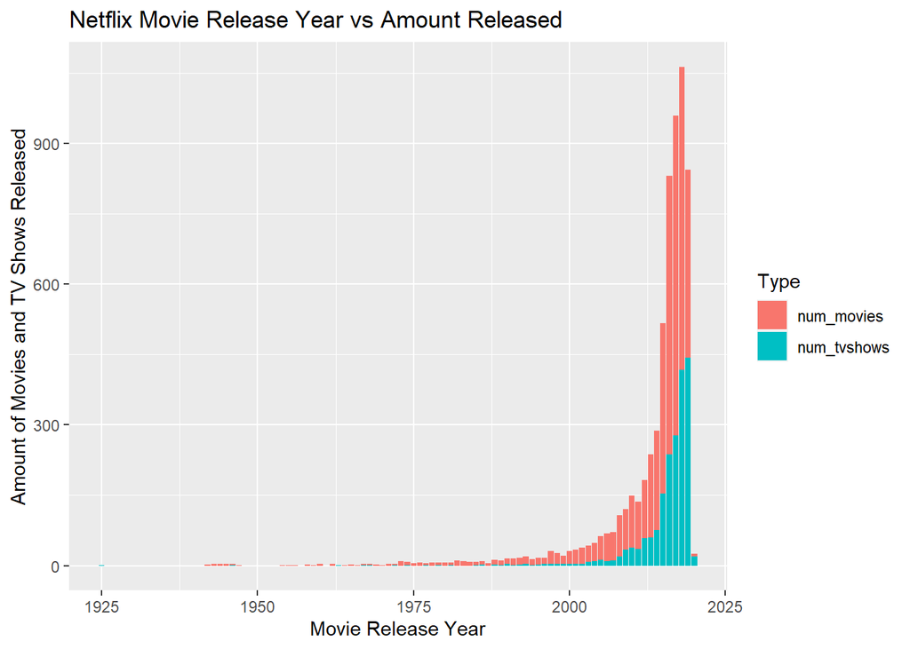

This chart is a stacked bar chart that compares the number of movies and TV shows released onto Netflix per year. A similar observation can be made as the aggregate table, that there were more movies made than TV shows in the 2000’s. There is also a exponential increase in the number of movies and TV shows in the 2000’s.

Chart 2

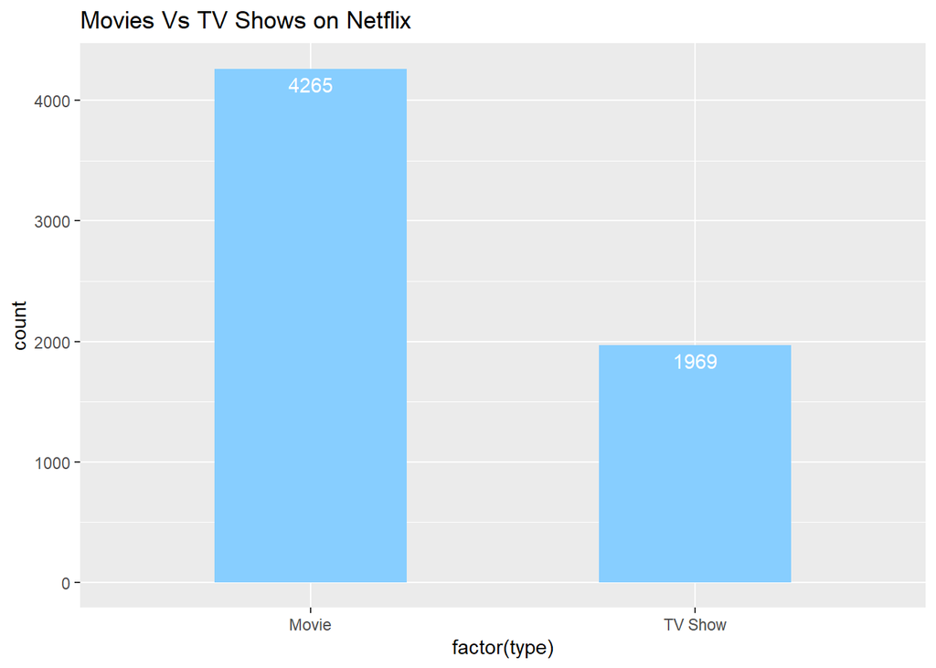

Chart 3

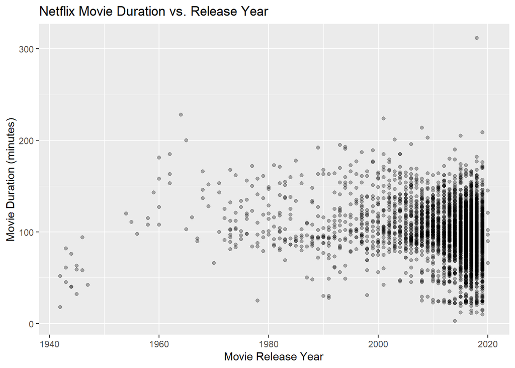